# Question

La imagen muestra dos gráficos relacionados con las exportaciones de Tebailandia, un país que usa “tebos” como su moneda.

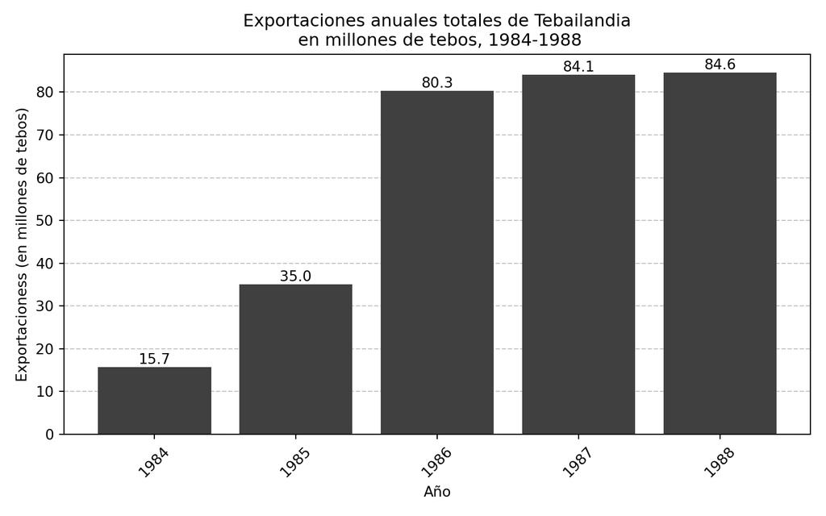

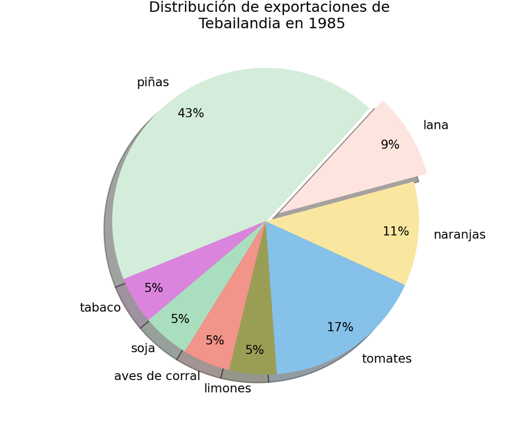

¿Cuál fue el valor de lana exportado desde Tebailandia en 1985?

## Answerlist

- 3.15 millones de tebos.
- 2.99 millones de tebos.
- 3.31 millones de tebos.
- 2.52 millones de tebos.

# Solution

**Análisis detallado del problema:**

Para resolver este problema de interpretación de gráficos estadísticos, necesitamos combinar información de dos representaciones gráficas diferentes: un gráfico de barras y un gráfico circular (torta).

**Paso 1: Identificación de los datos en el gráfico de barras**

El primer gráfico muestra las exportaciones anuales totales de Tebailandia en millones de tebos para el período 1984-1988. Los valores específicos para cada año son:

- Año 1984 : 15.7 millones de tebos
- Año 1985 : 35 millones de tebos
- Año 1986 : 80.3 millones de tebos
- Año 1987 : 84.1 millones de tebos
- Año 1988 : 84.6 millones de tebos

**Paso 2: Identificación del año específico y valor total**

Para el año 1985, el valor total de exportaciones fue de:

**Valor total de exportaciones en 1985 : 35 millones de tebos**

**Paso 3: Análisis del gráfico circular (distribución porcentual)**

El segundo gráfico muestra la distribución porcentual de las exportaciones de Tebailandia en 1985. Los productos y sus respectivos porcentajes son:

- lana: 9%
- piñas: 43%
- tabaco: 5%
- soja: 5%
- aves de corral: 5%
- limones: 5%
- tomates: 17%
- naranjas: 11%

**Paso 4: Identificación del producto específico**

El producto por el cual se pregunta es **lana**, que representa el **9%** del total de exportaciones en 1985.

**Paso 5: Cálculo matemático**

Para calcular el valor específico de lana exportado en 1985, aplicamos la siguiente fórmula:

**Valor del producto = Valor total × Porcentaje del producto**

Sustituyendo los valores:

Valor de lana = 35 millones de tebos × 9 % Valor de lana = 35 × 0.09 Valor de lana = 3.15 millones de tebos

**Paso 6: Verificación del resultado**

El cálculo nos da: **3.15 millones de tebos**

**Verificación de coherencia:**

- El resultado (3.15 millones) es menor que el total (35 millones), lo cual es lógico ya que representa solo una fracción del total.
- El porcentaje de lana (9%) multiplicado por el total debe dar exactamente nuestro resultado.
- Verificación: 35 × 9% = 35 × 0.09 = 3.15 (correcto)

**Paso 7: Análisis de las opciones distractoras**

Las otras opciones presentadas son:

- 2.99 millones de tebos (aproximadamente 95% del valor correcto)
- 3.31 millones de tebos (aproximadamente 105% del valor correcto)
- 2.52 millones de tebos (aproximadamente 80% del valor correcto)

Estas opciones están diseñadas para capturar errores comunes como:

- Errores de cálculo por redondeo prematuro
- Confusión en la aplicación de porcentajes
- Lectura incorrecta de los gráficos

**Conclusión:**

Por lo tanto, el valor de **lana** exportado desde Tebailandia en **1985** fue de **3.15 millones de tebos**.

Este problema evalúa competencias fundamentales en:

1. **Lectura e interpretación de gráficos estadísticos** (barras y circulares)
2. **Aplicación de porcentajes** en contextos reales
3. **Cálculos matemáticos** con números decimales
4. **Análisis crítico** de la información presentada en múltiples formatos

# Meta-information

exname: Problemattic-PISA-Exportaciones-01(single-choice) extype: schoice exsolution: 1000 exshuffle: TRUE